# Tugas Pertemuan 6

Fathoni Sabri

2025-10-02

# Library

```r
library(ggplot2)
library(tsibble)
library(tseries)
library(MASS)
library(dplyr)
library(TSA)
library(forecast)
```

# Input Data

```r
data<-read.csv("C:/Users/Fathoni Sabri/Downloads/data_fathoni.csv")
head(data)
```

```
##         Date     Close    Volume
## 1  10/9/2023  973.5909  22298500
## 2 10/10/2023 1213.2440  13625200
## 3 10/11/2023 1512.8105  38431400
## 4 10/12/2023 1887.2686 219262300
## 5 10/13/2023 2356.5891  39504100
## 6 10/16/2023 2746.0256 227720100
```

```r
str(data)
```

```
## 'data.frame':    111 obs. of  3 variables:
##  $ Date  : chr  "10/9/2023" "10/10/2023" "10/11/2023" "10/12/2023" ...
##  $ Close : num  974 1213 1513 1887 2357 ...
##  $ Volume: int  22298500 13625200 38431400 219262300 39504100 227720100 215604400 311694400 150507700 85371300 ...
```

## Data Formating

### Mengubah Format Tanggal

```r
data$Date <- as.Date(data$Date, format = "%m/%d/%Y")
head(data)
```

```
##         Date     Close    Volume
## 1 2023-10-09  973.5909  22298500
## 2 2023-10-10 1213.2440  13625200
## 3 2023-10-11 1512.8105  38431400
## 4 2023-10-12 1887.2686 219262300
## 5 2023-10-13 2356.5891  39504100
## 6 2023-10-16 2746.0256 227720100
```

### Memilih Kolom

```r
data <- data %>%
  select(Date, Close)
head(data)
```

```
##         Date     Close
## 1 2023-10-09  973.5909
## 2 2023-10-10 1213.2440
## 3 2023-10-11 1512.8105
## 4 2023-10-12 1887.2686
## 5 2023-10-13 2356.5891
## 6 2023-10-16 2746.0256
```

## Splitting Data

Data dibagi menjadi 80% dan 20%

```r
# hitung jumlah data
n <- nrow(data)
n_train <- floor(0.8 * n)

# bagi data
training <- data[1:n_train, ]
testing  <- data[(n_train+1):n, ]

# ubah ke time series
train <- ts(training$Close)
test  <- ts(testing$Close)
```

```r
length(train)
```

```
## [1] 88
```

# Eksplorasi Data

```r
mean <- mean(data$Close)
mean
```

```
## [1] 5523.31
```

## Plot Data Penuh

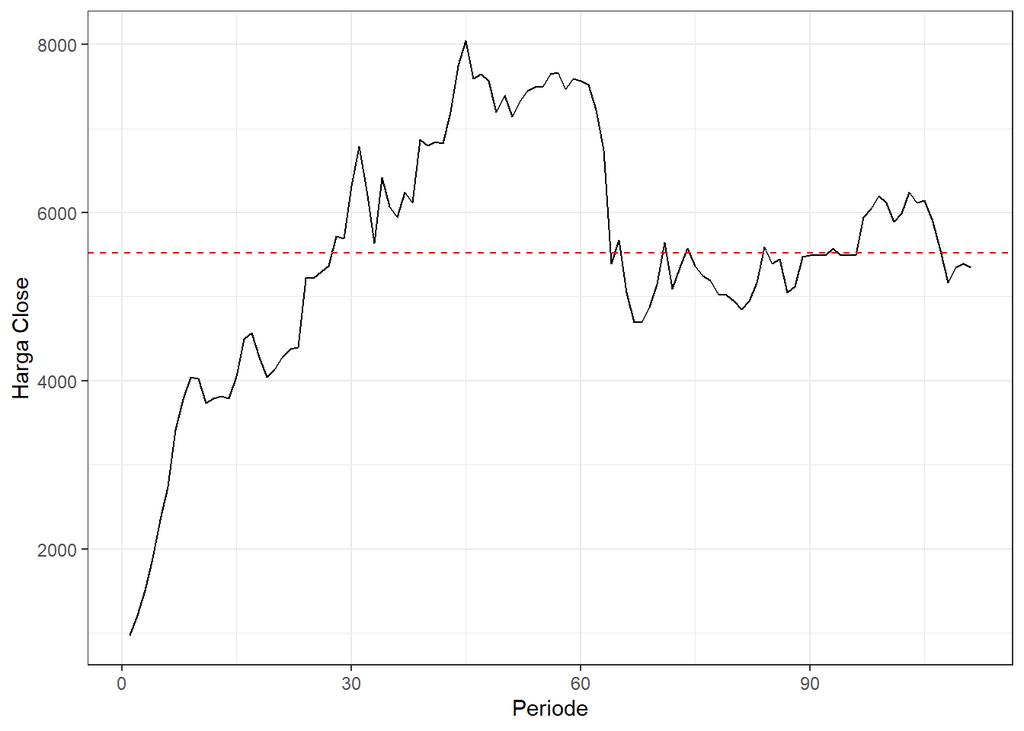

```r
dt <- ts(data$Close)

plot <- dt |> as_tsibble() |>
  ggplot(aes(x = index, y = value)) + geom_line() + theme_bw() +
  geom_hline(yintercept = mean, color = "red", linetype = "dashed") +
  xlab("Periode") + ylab("Harga Close")
plot
```

## Plot Data Latih

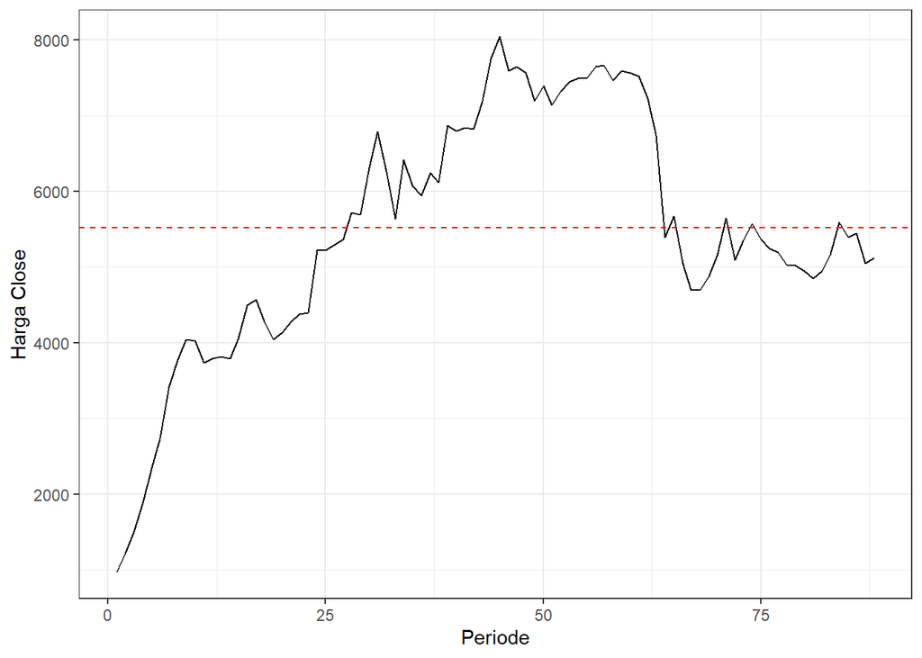

```r
dt.train <- ts(training$Close)

plot <- dt.train |> as_tsibble() |>
  ggplot(aes(x = index, y = value)) + geom_line() + theme_bw() +
  geom_hline(yintercept = mean, color = "red", linetype = "dashed") +
  xlab("Periode") + ylab("Harga Close")
plot
```

## Plot Data Uji

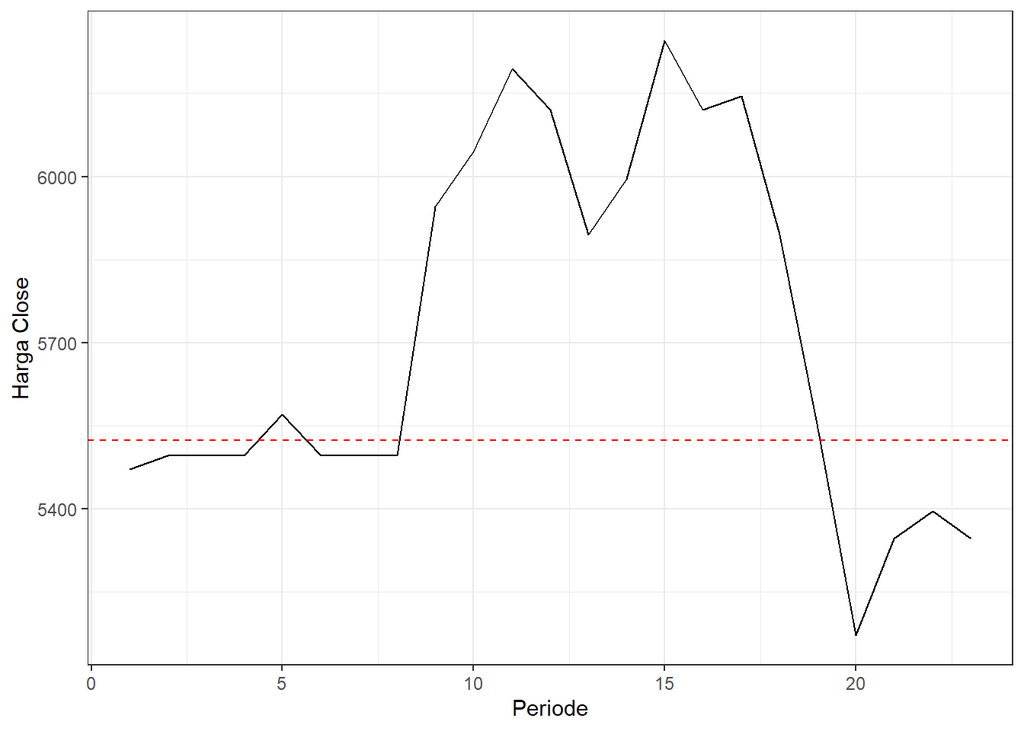

```r
dt.test <- ts(testing$Close)

plot <- dt.test |> as_tsibble() |>
  ggplot(aes(x = index, y = value)) + geom_line() + theme_bw() +
  geom_hline(yintercept = mean, color = "red", linetype = "dashed") +
  xlab("Periode") + ylab("Harga Close")
plot
```

# Pemeriksaan Kestasioneran Data

## Plot ACF

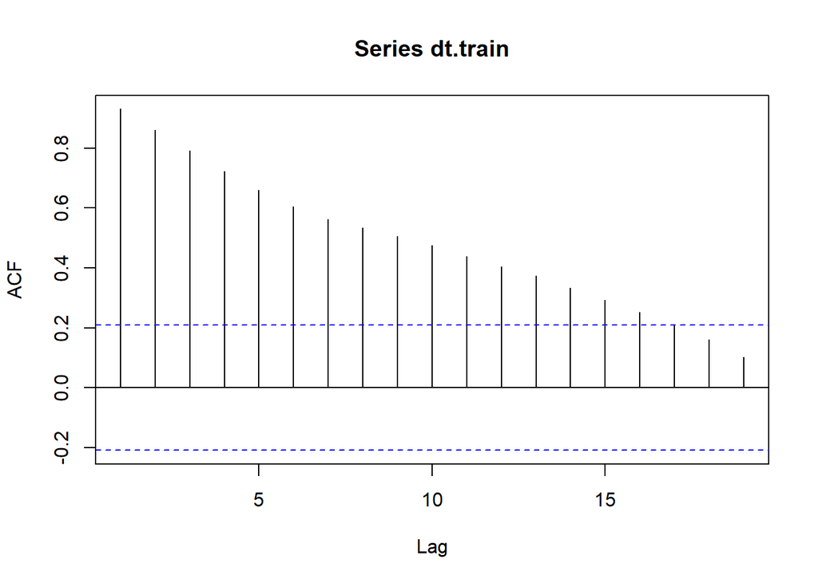

```r
acf(dt.train)
```

Terlihat bahwa data turun perlahan (tails off), ini mengindikasikan data tidak stasioner dalam rataan.

## Uji ADF

```r
tseries::adf.test(dt.train)
```

```
##
##  Augmented Dickey-Fuller Test
##
## data:  dt.train
## Dickey-Fuller = -1.8306, Lag order = 4, p-value = 0.6457
## alternative hypothesis: stationary
```

P-Value gagal menolak H0, artinya data tidak menyebar stasioner dalam rataan. Hal ini sesuai dengan plot ACF sebelumnya.

## Kestasioneran Dalam Ragam

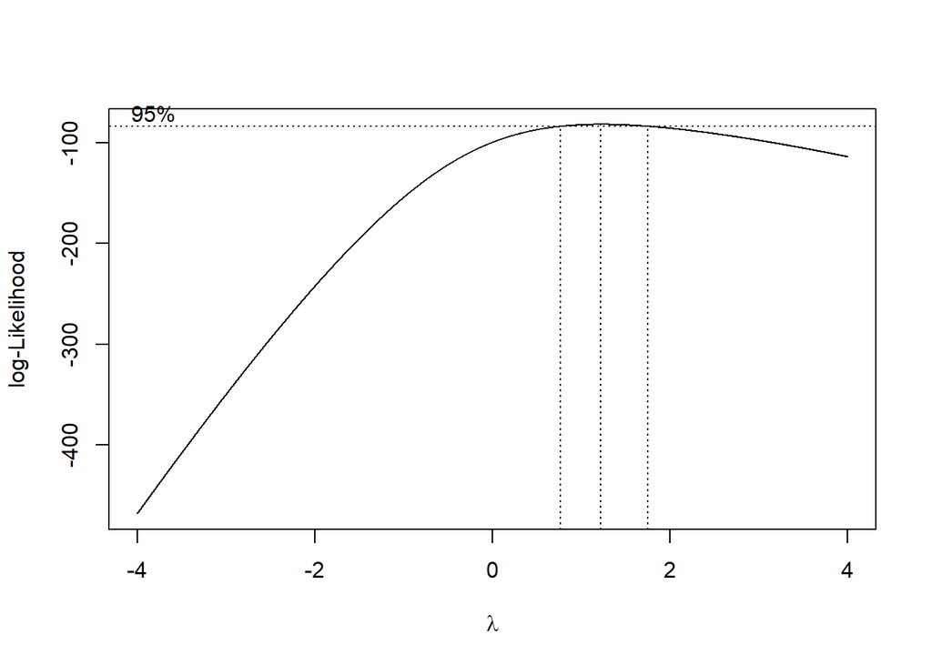

```r
index<-seq(1:88)

bc <- boxcox(
  dt.train ~ index,
  lambda = seq(-4.0, 4.0, by = 0.001)
)
```

```r
lambda <- bc$x[which.max(bc$y)]
lambda
```

```
## [1] 1.222
```

```r
ci_lambda <- bc$x[bc$y > max(bc$y) - 0.5 * qchisq(0.95, 1)]

ci_lower <- min(ci_lambda)
ci_upper <- max(ci_lambda)

c(Batas_Bawah = ci_lower, Batas_Atas = ci_upper)
```

```
## Batas_Bawah  Batas_Atas
##       0.768       1.752
```

Hasil analisis Box-Cox menunjukkan bahwa nilai λ=1 berada pada selang kepercayaan 0.768 hingga 1.752. Ini menunjukkan bahwa data menyebar stasioner terhadap varians.

# Penanganan Ketidakstasioneran

## Differencing

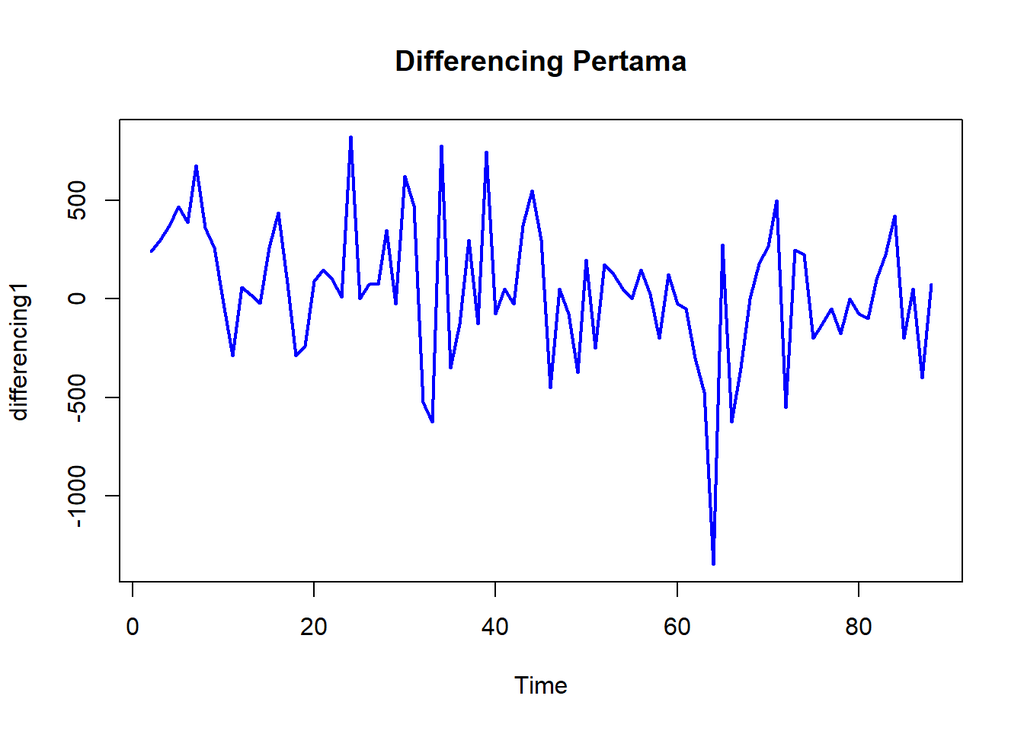

```r
differencing1 <- diff(dt.train, differences = 1)

ts.plot(differencing1,
        main = "Differencing Pertama",
        col = "blue", lwd = 2)
```

```r
length(differencing1)
```

```
## [1] 87
```

## Plot ACF Setelah Differencing

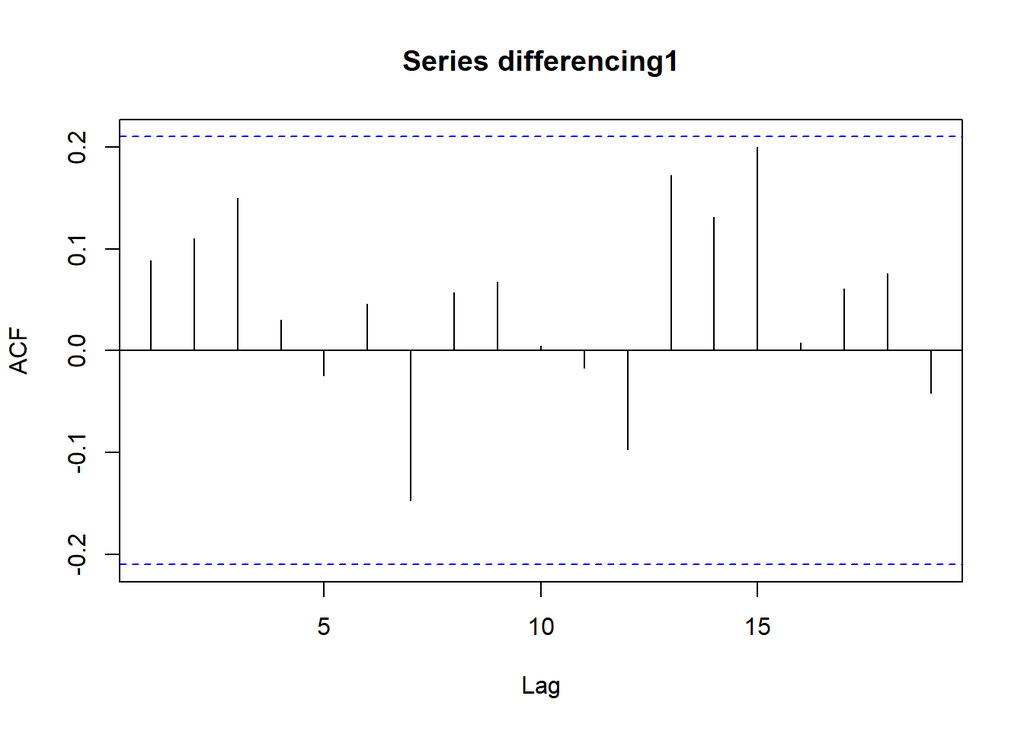

```r
acf(differencing1)
```

Terjadi perubahan, di mana plot ACF pada data yang tadinya tails off berubah menjadi cut off. Namun, untuk memastikan bahwa ketidakstasioneran pada data masih ada atau tidak. perlu dilakukan uji ADF. Selain itu, data cut of pada $Lag 0$.

## Uji ADF Setelah Differencing

```r
adf.test(differencing1)
```

```
##
##  Augmented Dickey-Fuller Test
##
## data:  differencing1
## Dickey-Fuller = -4.2067, Lag order = 4, p-value = 0.01
## alternative hypothesis: stationary
```

Uji ADF menghasilkan $P-value$ 0.01 yang lebih kecil dari nilai signifikannya. Sehingga, cukup bukti untuk mengatakan data telah stasioner dalam rataan.

## Ketidakstasioneran Dalam Varians Setelah Differencing

```r
length(differencing1)
```

```
## [1] 87
```

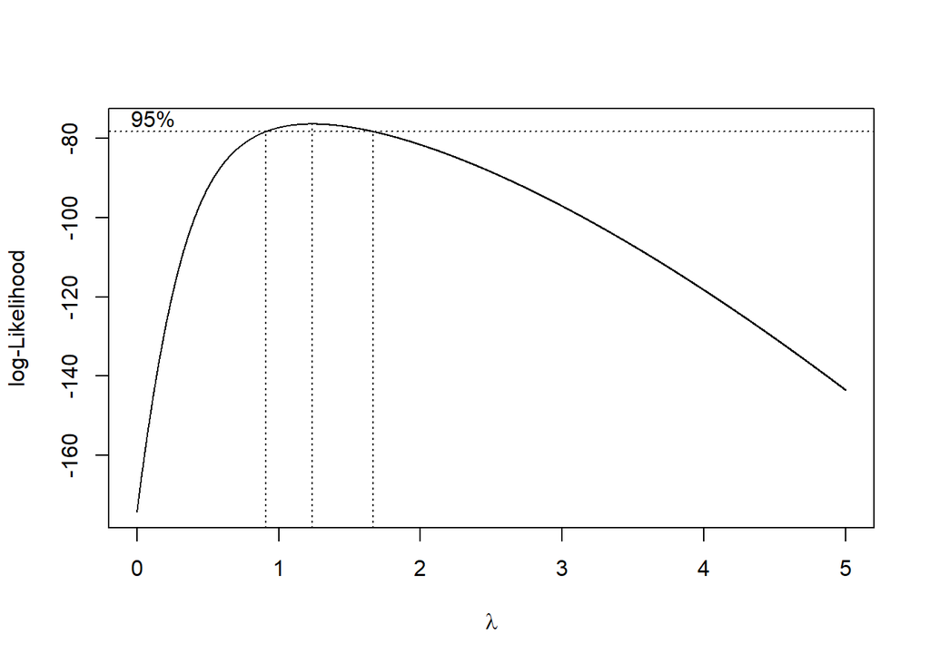

```r
index2 <- seq(1:87)

bc2 <- boxcox(
  differencing1 - min(differencing1) + 1 ~ index2,
  lambda = seq(0, 5, by = 0.001)
)
```

```r
lambda <- bc2$x[which.max(bc2$y)]
lambda
```

```
## [1] 1.236
```

```r
ci_lambda <- bc2$x[bc2$y > max(bc2$y) - 0.5 * qchisq(0.95, 1)]

ci_lower <- min(ci_lambda)
ci_upper <- max(ci_lambda)

c(Batas_Bawah = ci_lower, Batas_Atas = ci_upper)
```

```
## Batas_Bawah  Batas_Atas
##       0.908       1.664
```

Hasil analisis Box-Cox menunjukkan bahwa nilai λ=1 berada pada selang kepercayaan 0.908 hingga 1.664. Ini menunjukkan bahwa setelah dilakukan differencing, data tetap menyebar stasioner terhadap varians.

# Identifikasi Model

## 6.1 Plot ACF untuk MA(q)

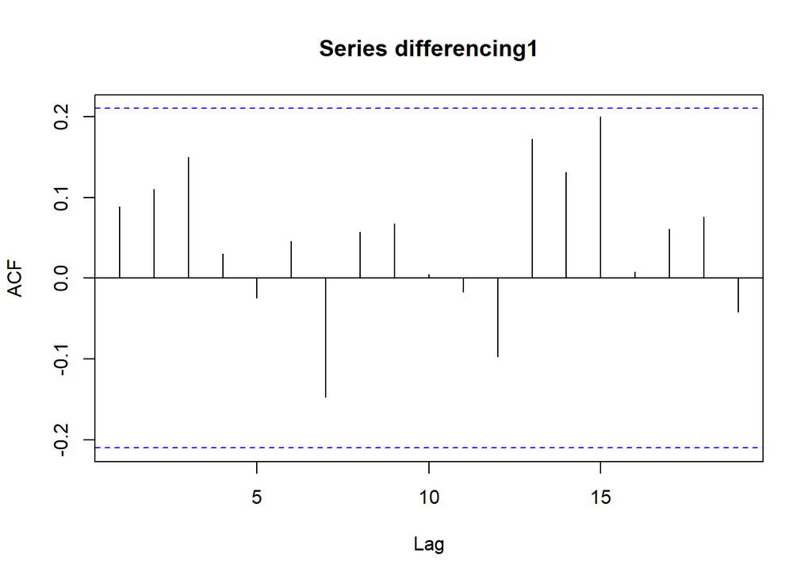

```r
acf(differencing1)
```

Berdasarkan plot tersebut, terlihat bahwa plot ACF cenderung cuts off pada lag ke 0.

## 6.2 Plot PACF untuk AR(p=)

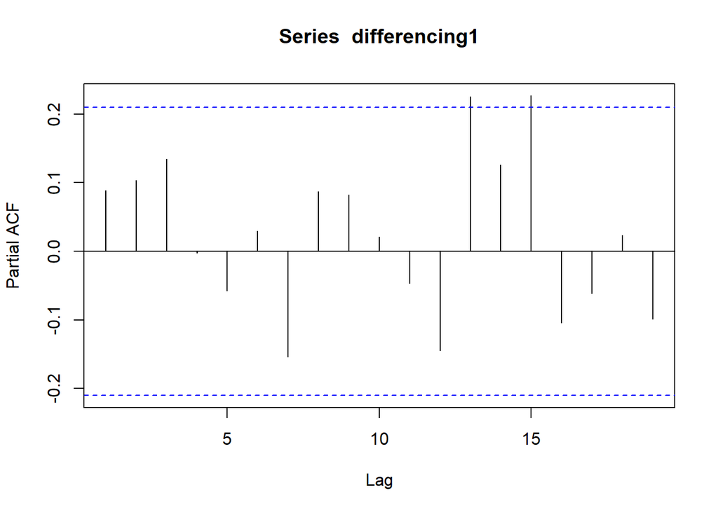

```r
pacf(differencing1)
```

```r
eacf(differencing1)
```

```
## AR/MA
##   0 1 2 3 4 5 6 7 8 9 10 11 12 13
## 0 o o o o o o o o o o o  o  o  o
## 1 x o o o o o o o o o o  o  o  o
## 2 x o o o o o o o o o o  o  o  o
## 3 o x o o o o o o o o o  o  o  o
## 4 o x o x o o o o o o o  o  o  o
## 5 x x o x o o o o o o o  o  o  o
## 6 o x o x o o o o o o o  o  o  o
## 7 x x x o o o o o o o o  o  o  o
```

maka model tentatifnya adalah ARIMA(0,1,0). Sebagai perbandingan, kita juga akan melihat hasil dari model ARIMA(1,1,1).

# Pendugaan Parameter Model Tentatif

### ARIMA(0,1,0)

```r
model1 = Arima(differencing1, order=c(0,1,0), method="ML", include.drift = TRUE)
summary(model1)
```

```
## Series: differencing1
## ARIMA(0,1,0) with drift
##
## Coefficients:
##         drift
##       -1.9152
## s.e.  50.4047
##
## sigma^2 = 221065:  log likelihood = -650.69
## AIC=1305.39   AICc=1305.53   BIC=1310.29
##
## Training set error measures:
##                       ME     RMSE      MAE MPE MAPE      MASE       ACF1
## Training set 0.002776646 464.7395 330.5924 NaN  Inf 0.9883824 -0.5128758
```

```r
lmtest::coeftest(model1)
```

```
##
## z test of coefficients:
##
##       Estimate Std. Error z value Pr(>|z|)
## drift  -1.9152    50.4047  -0.038   0.9697
```

Drift tidak signifikan, artinya data Data sudah stasioner dan tidak punya tren deterministik.

### ARIMA(1,1,1)

```r
model2 = Arima(differencing1, order=c(1,1,1), method="ML")
summary(model2)
```

```
## Series: differencing1
## ARIMA(1,1,1)
##
## Coefficients:
##          ar1      ma1
##       0.0148  -0.9280
## s.e.  0.1158   0.0483
##
## sigma^2 = 120766:  log likelihood = -625.16
## AIC=1256.32   AICc=1256.61   BIC=1263.68
##
## Training set error measures:
##                     ME     RMSE      MAE MPE MAPE      MASE        ACF1
## Training set -47.52319 341.4691 255.5505 NaN  Inf 0.7640271 -0.03083367
```

```r
lmtest::coeftest(model2)
```

```
##
## z test of coefficients:
##
##      Estimate Std. Error z value Pr(>|z|)
## ar1  0.014822   0.115782   0.128   0.8981
## ma1 -0.927991   0.048290 -19.217   <2e-16 ***
## ---
## Signif. codes:  0 '***' 0.001 '**' 0.01 '*' 0.05 '.' 0.1 ' ' 1
```

Pada Model ARIMA(1,1,1) hanya 1 parameter saja yang signifikan.

## Ringkasan AIC

```r
model_tentatif <- data.frame(
  Model = c("ARIMA(0,1,0)","ARIMA(1,1,1)"),
  AIC   = c(AIC(model1),AIC(model2)),
  BIC   = c(BIC(model1),BIC(model2))
)

model_tentatif
```

```
##          Model      AIC      BIC
## 1 ARIMA(0,1,0) 1305.386 1310.294
## 2 ARIMA(1,1,1) 1256.319 1263.682
```

Berdasarkan Nilai AIC terkecil, Model ARIMA (1,1,1) dipilih sebagai model.

# Analisis Sisaan

## Eksplorasi Sisaan

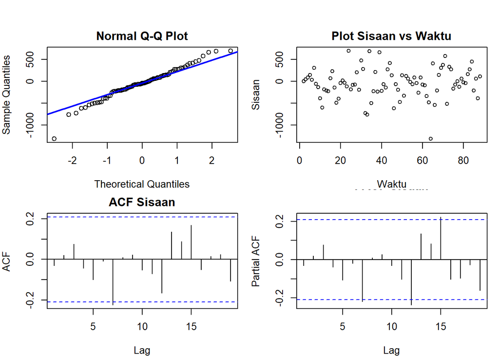

```r
  sisaan <- model2$residuals

  par(mfrow = c(2,2),
      mar = c(4,4,2,1),
      oma = c(0,0,2,0))

  # Q-Q Plot
  qqnorm(sisaan, main = "Normal Q-Q Plot")
  qqline(sisaan, col = "blue", lwd = 2)

  # Plot Sisaan vs Waktu
  plot(sisaan, type = "p",
       main = "Plot Sisaan vs Waktu",
       xlab = "Waktu", ylab = "Sisaan")

  # ACF
  acf(sisaan, main = "ACF Sisaan")

  # PACF
  pacf(sisaan, main = "PACF Sisaan")
```

## Uji Formal

```r
ks.test(sisaan,"pnorm")
```

```
##
##  Exact one-sample Kolmogorov-Smirnov test
##
## data:  sisaan
## D = 0.56322, p-value < 2.2e-16
## alternative hypothesis: two-sided
```

Berdasarkan uji KS tersebut, didapat p-value sebesar $0.0000$ yang kurang dari taraf nyata 5% sehingga tolak $H_0$ dan menandakan bahwa sisaan tidak menyebar normal. Hal ini sesuai dengan hasil eksplorasi menggunakan plot kuantil-kuantil normal.

```r
Box.test(sisaan, type = "Ljung")
```

```
##
##  Box-Ljung test
##
## data:  sisaan
## X-squared = 0.085598, df = 1, p-value = 0.7699
```

Berdasarkan uji Ljung-Box tersebut, didapat p-value sebesar $0.7699$ yang lebih besar dari taraf nyata 5% sehingga gagal tolak $H_0$ dan menandakan bahwa sisaan saling bebas. Hal ini sesuai dengan hasil eksplorasi.

```r
Box.test((sisaan)^2, type = "Ljung")
```

```
##
##  Box-Ljung test
##
## data:  (sisaan)^2
## X-squared = 3.6426, df = 1, p-value = 0.05632
```

Berdasarkan uji Ljung-Box terhadap sisaan kuadrat tersebut, didapat p-value sebesar $0.05632$ yang lebih besar dari taraf nyata 5% sehingga tak tolak $H_0$ dan menandakan bahwa tak cukup bukti untuk mengatakan ragam sisaan tidak homogen.

```r
t.test(sisaan, mu = 0, conf.level = 0.95)
```

```
##
##  One Sample t-test
##
## data:  sisaan
## t = -1.3033, df = 86, p-value = 0.1959
## alternative hypothesis: true mean is not equal to 0
## 95 percent confidence interval:
##  -120.00968   24.96329
## sample estimates:
## mean of x
## -47.52319
```

Berdasarkan uji t satu sampel terhadap sisaan model ARIMA(1,1,1), diperoleh nilai p = 0.1959 (> 0.05) sehingga gagal menolak hipotesis nol. Hal ini menunjukkan bahwa rata-rata sisaan tidak berbeda signifikan dari nol. Dengan demikian, model tidak mengandung bias sistematis dalam prediksi, dan asumsi nilai tengah sisaan = 0 telah terpenuhi. Hal ini sesuai dengan eksplorasi yang telah dilakukan.

# Overfitting

Tahapan selanjutnya adalah overfitting dilakukan dengan menaikkan orde AR(p) dan MA(q) dari model ARIMA(1,1,1) Kandidat model overfitting adalah ARIMA(2,1,1) dan ARIMA(1,1,2).

# ARIMA (2,1,1)

```r
model3 = Arima(differencing1, order=c(2,1,1), method="ML")
summary(model3)
```

```
## Series: differencing1
## ARIMA(2,1,1)
##
## Coefficients:
##          ar1     ar2      ma1
##       0.0214  0.0527  -0.9355
## s.e.  0.1155  0.1145   0.0463
##
## sigma^2 = 121915:  log likelihood = -625.05
## AIC=1258.11   AICc=1258.6   BIC=1267.92
##
## Training set error measures:
##                     ME     RMSE      MAE MPE MAPE      MASE        ACF1
## Training set -48.70135 341.0423 256.0735 NaN  Inf 0.7655909 -0.03666833
```

```r
lmtest::coeftest(model3)
```

```
##
## z test of coefficients:
##
##      Estimate Std. Error  z value Pr(>|z|)
## ar1  0.021372   0.115497   0.1850   0.8532
## ar2  0.052749   0.114490   0.4607   0.6450
## ma1 -0.935516   0.046301 -20.2052   <2e-16 ***
## ---
## Signif. codes:  0 '***' 0.001 '**' 0.01 '*' 0.05 '.' 0.1 ' ' 1
```

pada ARIMA(2,1,1) dengan menaikkan satu ordo AR ternyata tidak lebih baik dari Model ARIMA(1,1,1). Karena nilai AIC dari Model ARIMA(2,1,1) lebih besar serta ada dua parameter yang tidak siginifikan, yaitu ar1 dan ar2.

## ARIMA(1,1,2)

```r
model4 = Arima(differencing1, order=c(1,1,2), method="ML")
summary(model4)
```

```
## Series: differencing1
## ARIMA(1,1,2)
##
## Coefficients:
```

```
##           ar1      ma1      ma2
##       -0.3769  -0.5422  -0.3557
## s.e.      NaN      NaN      NaN
##
## sigma^2 = 122243:  log likelihood = -625.16
## AIC=1258.33   AICc=1258.82   BIC=1268.15
##
## Training set error measures:
##                     ME     RMSE     MAE MPE MAPE      MASE        ACF1
## Training set -47.09998 341.5008 255.395 NaN  Inf 0.7635622 -0.02363055
```

```r
lmtest::coeftest(model4)
```

```
## Warning in sqrt(diag(se)): NaNs produced
```

```
##
## z test of coefficients:
##
##     Estimate Std. Error z value Pr(>|z|)
## ar1 -0.37689        NaN     NaN      NaN
## ma1 -0.54222        NaN     NaN      NaN
## ma2 -0.35571        NaN     NaN      NaN
```

Muncul peringatan “NaNs produced”.

```r
model5<-forecast::Arima(differencing1, order=c(1,1,2))
```

```r
lmtest::coeftest(model5)
```

```
##
## z test of coefficients:
##
##     Estimate Std. Error z value Pr(>|z|)
## ar1 -0.81651    0.92596 -0.8818   0.3779
## ma1 -0.11268    0.94671 -0.1190   0.9053
## ma2 -0.75205    0.88028 -0.8543   0.3929
```

ARIMA(1,1,2) dengan menaikkan satu ordo MA ternyata masih tidak lebih baik dari Model ARIMA(1,1,1). Karena nilai AIC dari Model ARIMA(1,1,2) lebih besar serta tidak ada parameter yang signifikan pada alpha 5%.

Karena model hasil overfitting hasilnya tidak lebih baik daripada Model ARIMA(1,1,1), maka model terbaik yang dipilih adalah ARIMA(1,1,1) dilanjutkan dengan peramalan.

# Model Terbaik: ARIMA(1,1,1)

```r
model2 = Arima(differencing1, order=c(1,1,1), method="ML")
summary(model2)
```

```
## Series: differencing1
## ARIMA(1,1,1)
##
## Coefficients:
##          ar1      ma1
##       0.0148  -0.9280
## s.e.  0.1158   0.0483
##
## sigma^2 = 120766:  log likelihood = -625.16
## AIC=1256.32   AICc=1256.61   BIC=1263.68
##
## Training set error measures:
##                     ME     RMSE      MAE MPE MAPE      MASE        ACF1
## Training set -47.52319 341.4691 255.5505 NaN  Inf 0.7640271 -0.03083367
```

```r
lmtest::coeftest(model2)
```

```
##
## z test of coefficients:
##
##      Estimate Std. Error z value Pr(>|z|)
## ar1  0.014822   0.115782   0.128   0.8981
## ma1 -0.927991   0.048290 -19.217   <2e-16 ***
## ---
## Signif. codes:  0 '***' 0.001 '**' 0.01 '*' 0.05 '.' 0.1 ' ' 1
```

Nilai AIC: $1256.32$  
Nilai AICc: $1256.61$  
Nilai BIC: $1263.68$  
Parameter ma1 signifikan pada taraf nyata 5%

# Peramalan

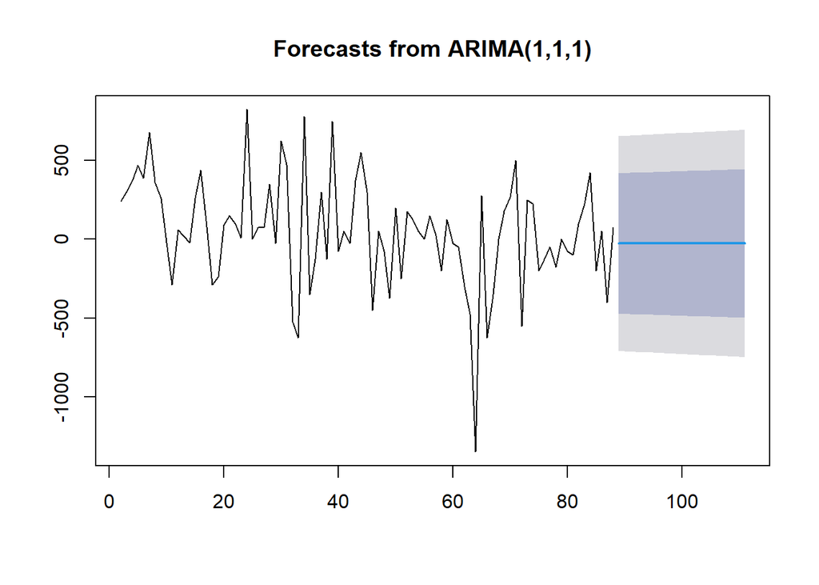

```r
ramalan <- forecast::forecast(model2, h = length(dt.test))

data.ramalan <- ramalan$mean
plot(ramalan)
```

```r
# Inverse differencing
pt_akhir_train <- tail(dt.test, 1)

forecast <- diffinv(data.ramalan, differences = 1, xi = pt_akhir_train)
hasil <- forecast[-c(0,1)]
hasil <- forecast[1:length(dt.test)]

# Bandingkan aktual vs forecast
perbandingan <- cbind(
  Aktual   = dt.test,
  Forecast = hasil
)

print(head(perbandingan, 10))
```

```
## Time Series:
## Start = 1
## End = 10
## Frequency = 1
##      Aktual Forecast
##  1 5470.873 5345.967
##  2 5495.854 5320.577
##  3 5495.854 5293.700
##  4 5495.854 5266.801
##  5 5570.798 5239.902
##  6 5495.854 5213.002
##  7 5495.854 5186.102
##  8 5495.854 5159.203
##  9 5945.515 5132.303
## 10 6045.440 5105.404
```

```r
akurasi_test <- accuracy(hasil, dt.test)
akurasi_test
```

```
##                ME     RMSE      MAE      MPE     MAPE     ACF1 Theil's U
## Test set 662.6307 761.6958 662.6307 11.31225 11.31225 0.837394  4.054315
```

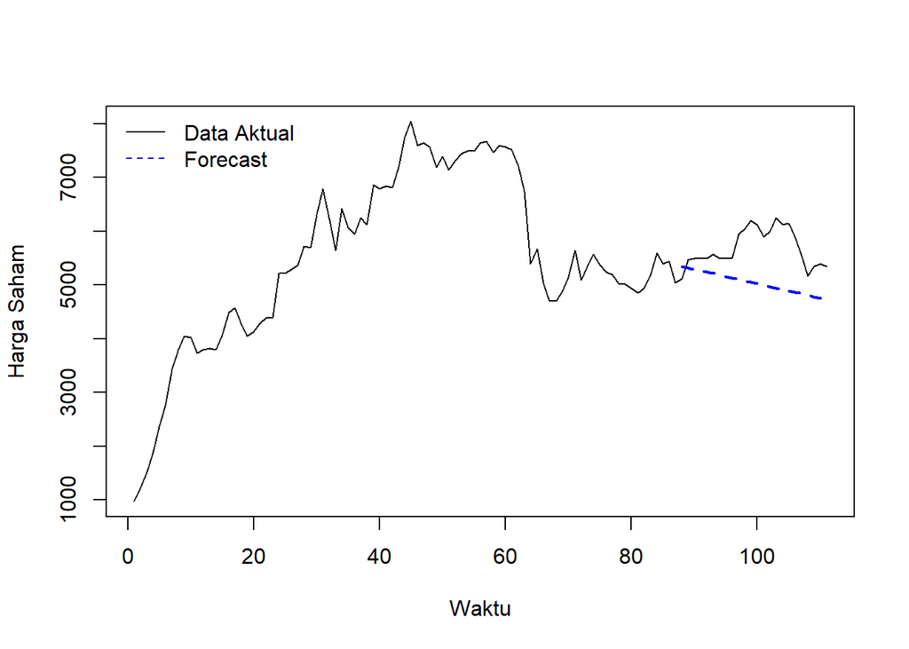

```r
ts.plot(dt, col = "black", lty = 1,
        xlab = "Waktu", ylab = "Harga Saham")

lines(88:(87+length(hasil)), hasil, col = "blue", lty = 2, lwd = 2)
legend("topleft",
       legend = c("Data Aktual", "Forecast"),
       col = c("black", "blue"),
       lty = c(1,2,3), lwd = c(1,1,1), bty = "n")
```

Berdasarkan hasil peramalan, dapat dilihat bahwa nilai MAPE yang didapatkan sebesar 11,31% yang sebenarnya masih cukup baik untuk model tersebut, tetapi dikarenakan nilai ACF1 dan Theil’s U yang besar menunjukkan model belum menangkap pola autokorelasi residual dengan baik. Peramalan ini hanya cocok untuk jangka pendek.